# Vehicle Loan Defaulter Prediction

[figure not shown]

1. Introduction
2. Importing the neccessary libraries
3. Reading the dataset
4. Handling missing values
5. Descriptive analysis
   - Continous variables
   - Categorical variables
6. EDA
7. Correlation Matrix
8. Conclusion

# 1. Introduction

### Problem statement

Banks run into losses when a customer doesn't pay their vehicle loans on time. Because of this, every year, banks have losses in crores, and this also impacted vehicle loan underwriting and increased vehicle loan rejection rates. So, I take this as an opportunity to clean, process and visualize the data on the various attributes such as funded amount, location, loan, balance, etc. to find insights and prepare the data for a machine learning model.

Data Set : https://www.kaggle.com/datasets/avikpaul4u/vehicle-loan-default-prediction

### About the dataset

The following train data consists of 41 column and 233154 rows covering three major areas.

#### Areas

| S.No |  | Area Type |  | Column Details |
| --- | --- | --- | --- | --- |
| 1 |  | Loanee Information |  | Demographic data like age, income, Identity proof etc. |
| 2 |  | Loan Information |  | Disbursal details, amount, EMI, loan to value ratio etc. |
| 3 |  | Bureau data & history |  | Bureau score, number of active accounts, the status of other loans, credit history etc. |

## 2. Import the necessary Libraries

```python
import numpy as np
import pandas as pd
from numpy import mean
from numpy import std
import matplotlib.pyplot as plt
%matplotlib inline
import seaborn as sns
from scipy.stats import skewnorm
from plotly.subplots import make_subplots
import warnings
warnings.filterwarnings('ignore')
```

## 3. Reading the dataset

```python
# import data
df = pd.read_csv('C:/Users/manoharan/Documents/Study/DA-BA Projects/EDA Python - Vehicle Loan Default Prediction/train.csv')
```

```python
# Shape of data frame

print('Shape of train dataframe : ', df.shape)
```

```
Shape of train dataframe :  (233154, 41)
```

```python
# Column details

print('Name of columns\n',df.columns)
```

```
Name of columns
 Index(['UNIQUEID', 'DISBURSED_AMOUNT', 'ASSET_COST', 'LTV', 'BRANCH_ID',
       'SUPPLIER_ID', 'MANUFACTURER_ID', 'CURRENT_PINCODE_ID', 'DATE_OF_BIRTH',
       'EMPLOYMENT_TYPE', 'DISBURSAL_DATE', 'STATE_ID', 'EMPLOYEE_CODE_ID',
       'MOBILENO_AVL_FLAG', 'AADHAR_FLAG', 'PAN_FLAG', 'VOTERID_FLAG',
       'DRIVING_FLAG', 'PASSPORT_FLAG', 'PERFORM_CNS_SCORE',
       'PERFORM_CNS_SCORE_DESCRIPTION', 'PRI_NO_OF_ACCTS', 'PRI_ACTIVE_ACCTS',
       'PRI_OVERDUE_ACCTS', 'PRI_CURRENT_BALANCE', 'PRI_SANCTIONED_AMOUNT',
       'PRI_DISBURSED_AMOUNT', 'SEC_NO_OF_ACCTS', 'SEC_ACTIVE_ACCTS',
       'SEC_OVERDUE_ACCTS', 'SEC_CURRENT_BALANCE', 'SEC_SANCTIONED_AMOUNT',
       'SEC_DISBURSED_AMOUNT', 'PRIMARY_INSTAL_AMT', 'SEC_INSTAL_AMT',
       'NEW_ACCTS_IN_LAST_SIX_MONTHS', 'DELINQUENT_ACCTS_IN_LAST_SIX_MONTHS',
       'AVERAGE_ACCT_AGE', 'CREDIT_HISTORY_LENGTH', 'NO_OF_INQUIRIES',
       'LOAN_DEFAULT'],
      dtype='object')
```

```python
# Table view
df.head()
```

|  | UNIQUEID | DISBURSED_AMOUNT | ASSET_COST | LTV | BRANCH_ID | SUPPLIER_ID | MANUFACTURER_ID | CURRENT_PINCODE_ID | DATE_OF_BIRTH | EMPLOYMENT_TYPE | ... | SEC_SANCTIONED_AMOUNT | SEC_DISBURSED_AMOUNT | PRIMARY_INSTAL_AMT | SEC_INSTAL_AMT | NEW_ACCTS_IN_LAST_SIX_MONTHS | DELINQUENT_ACCTS_IN_LAST_SIX_MONTHS | AVERAGE_ACCT_AGE | CREDIT_HISTORY_LENGTH | NO_OF_INQUIRIES | LOAN_DEFAULT |
| --- | --- | --- | --- | --- | --- | --- | --- | --- | --- | --- | --- | --- | --- | --- | --- | --- | --- | --- | --- | --- | --- |
| 0 | 420825 | 50578 | 58400 | 89.55 | 67 | 22807 | 45 | 1441 | 01-01-1984 | Salaried | ... | 0 | 0 | 0 | 0 | 0 | 0 | 0yrs 0mon | 0yrs 0mon | 0 | 0 |
| 1 | 537409 | 47145 | 65550 | 73.23 | 67 | 22807 | 45 | 1502 | 31-07-1985 | Self employed | ... | 0 | 0 | 1991 | 0 | 0 | 1 | 1yrs 11mon | 1yrs 11mon | 0 | 1 |
| 2 | 417566 | 53278 | 61360 | 89.63 | 67 | 22807 | 45 | 1497 | 24-08-1985 | Self employed | ... | 0 | 0 | 0 | 0 | 0 | 0 | 0yrs 0mon | 0yrs 0mon | 0 | 0 |
| 3 | 624493 | 57513 | 66113 | 88.48 | 67 | 22807 | 45 | 1501 | 30-12-1993 | Self employed | ... | 0 | 0 | 31 | 0 | 0 | 0 | 0yrs 8mon | 1yrs 3mon | 1 | 1 |
| 4 | 539055 | 52378 | 60300 | 88.39 | 67 | 22807 | 45 | 1495 | 09-12-1977 | Self employed | ... | 0 | 0 | 0 | 0 | 0 | 0 | 0yrs 0mon | 0yrs 0mon | 1 | 1 |

5 rows × 41 columns

## 4. Handling missing values and variable inspection

### Missing Values

```
Null Values
        Column name  Total Count  Percentage Miss
0  EMPLOYMENT_TYPE         7661             3.29
```

```
<function matplotlib.pyplot.show(close=None, block=None)>
```

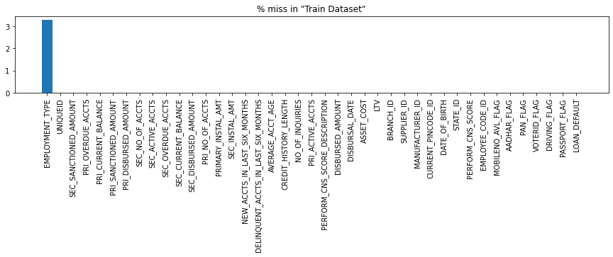

```python
# Check for null values

# Null values in train dataset
null = df.isnull().sum().sort_values(ascending = False)
Total = df.shape[0]
missing_percent = (round(((df.isnull().sum()/Total)*100),2)).sort_values(ascending = False)

missing_data = pd.concat([null,missing_percent],axis=1, keys =['Total Count','Percentage Miss'])

# Reset index and rename columns
missing_data.reset_index(inplace=True)
missing_data = missing_data.rename(columns = {'index':'Column name'})
# Null values count
print("Null Values \n",missing_data.head(1))
# Plot as bar graph
plt.figure(figsize=(15,2))
plt.bar(missing_data['Column name'],missing_data['Percentage Miss'])
plt.title('% miss in "Train Dataset"')
plt.xticks(rotation=90)
plt.show
```

#### Missing value details

| Data |  | Column Name |  | Total count |  | Percentage |
| --- | --- | --- | --- | --- | --- | --- |
| Dataset |  | EMPLOYMENT_TYPE |  | 7661 |  | 3.29 |

#### Missing value treatment

```python
# Check variable details in 'EMPLOYMENT TYPE'

df_null_unique = df.EMPLOYMENT_TYPE.unique()

print('Variables :\n',df_null_unique)
```

```
Variables :
 ['Salaried' 'Self employed' nan]
```

```python
# Fill the missing values

df.EMPLOYMENT_TYPE = df.EMPLOYMENT_TYPE.fillna('Missing')

df_null_unique = df.EMPLOYMENT_TYPE.unique()

print('Variables :\n',df_null_unique)
```

```
Variables :
 ['Salaried' 'Self employed' 'Missing']
```

#### Findings

- The whole dataset has only one column with null values (Employement Type) which is about 3% approx.
- And the null values have been replaced with 'Missing' to make the variable stable for visualizing.

### Varaiable type

```python
print(df.info())
```

```
<class 'pandas.core.frame.DataFrame'>
RangeIndex: 233154 entries, 0 to 233153
Data columns (total 41 columns):
 #   Column                               Non-Null Count   Dtype
---  ------                               --------------   -----
 0   UNIQUEID                             233154 non-null  int64
 1   DISBURSED_AMOUNT                     233154 non-null  int64
 2   ASSET_COST                           233154 non-null  int64
 3   LTV                                  233154 non-null  float64
 4   BRANCH_ID                            233154 non-null  int64
 5   SUPPLIER_ID                          233154 non-null  int64
 6   MANUFACTURER_ID                      233154 non-null  int64
 7   CURRENT_PINCODE_ID                   233154 non-null  int64
 8   DATE_OF_BIRTH                        233154 non-null  object
 9   EMPLOYMENT_TYPE                      233154 non-null  object
```

[output cut: 34 more lines]

### Observations

There are list for variables which need to be changed to the correct data type to proceed further on analysis. Find below the data type converstion details of the variables

| S No |  | Column Names |  | Current Data Type |  | Need to be |
| --- | --- | --- | --- | --- | --- | --- |
| 1 |  | 'DATE_OF_BIRTH', 'DISBURSAL_DATE' |  | Object |  | Date |
| 2 |  | 'AVERAGE_ACCT_AGE','CREDIT_HISTORY_LENGTH' |  | Object |  | Integer |
| 3 |  | 'UNIQUEID', 'BRANCH_ID','SUPPLIER_ID','MANUFACTURER_ID','CURRENT_PINCODE_ID', 'STATE_ID','EMPLOYEE_CODE_ID','MOBILENO_AVL_FLAG', 'AADHAR_FLAG', 'PAN_FLAG','VOTERID_FLAG', 'DRIVING_FLAG','PASSPORT_FLAG… |  | Integer |  | Object |

```python
### Change data type

# 1. DATE_OF_BIRTH & DISBURSAL_DATE

df['DATE_OF_BIRTH'] = pd.to_datetime(df['DATE_OF_BIRTH'],format = '%d-%m-%Y')
df['DISBURSAL_DATE'] = pd.to_datetime(df['DISBURSAL_DATE'],format = '%d-%m-%Y')

df[['DATE_OF_BIRTH','DISBURSAL_DATE']].info()
```

```
<class 'pandas.core.frame.DataFrame'>
RangeIndex: 233154 entries, 0 to 233153
Data columns (total 2 columns):
 #   Column          Non-Null Count   Dtype
---  ------          --------------   -----
 0   DATE_OF_BIRTH   233154 non-null  datetime64[ns]
 1   DISBURSAL_DATE  233154 non-null  datetime64[ns]
dtypes: datetime64[ns](2)
memory usage: 3.6 MB
```

```python
# 2. AVERGAE_ACCT_AGE, CREDIT_HISTORY_LENGTH

# Split year and month
df[['AVG_ACCT_Yr','AVG_ACCT_Month']] = df['AVERAGE_ACCT_AGE'].str.split("yrs",expand=True)
df[['AVG_ACCT_Month','AVG_ACCT_Month1']] = df['AVG_ACCT_Month'].str.split("mon",expand=True)

# To get avergae age convert both columns 'AVG_ACCT_Yr' & 'AVG_ACCT_Month' to Years and add them
df["AVERAGE_ACCT_AGE"]= round(df["AVG_ACCT_Yr"].astype(str).astype(int)+((df["AVG_ACCT_Month"].astype(str).astype(int))/12),1)

# drop other columns
df = df.drop(columns =['AVG_ACCT_Yr','AVG_ACCT_Month','AVG_ACCT_Month1'])

# Implement similar steps for CREDIT_HISTORY_LENGTH
df[['CRD_ACCT_Yr','CRD_ACCT_Month']] = df['CREDIT_HISTORY_LENGTH'].str.split("yrs",expand=True)
df[['CRD_ACCT_Month','CRD_ACCT_Month1']] = df['CRD_ACCT_Month'].str.split("mon",expand=True)
df["CREDIT_HISTORY_LENGTH"]= round(df["CRD_ACCT_Yr"].astype(str).astype(int)+((df["CRD_ACCT_Month"].astype(str).astype(int))/12),1)
df = df.drop(columns =['CRD_ACCT_Yr','CRD_ACCT_Month','CRD_ACCT_Month1'])


df.head(5)
```

|  | UNIQUEID | DISBURSED_AMOUNT | ASSET_COST | LTV | BRANCH_ID | SUPPLIER_ID | MANUFACTURER_ID | CURRENT_PINCODE_ID | DATE_OF_BIRTH | EMPLOYMENT_TYPE | ... | SEC_SANCTIONED_AMOUNT | SEC_DISBURSED_AMOUNT | PRIMARY_INSTAL_AMT | SEC_INSTAL_AMT | NEW_ACCTS_IN_LAST_SIX_MONTHS | DELINQUENT_ACCTS_IN_LAST_SIX_MONTHS | AVERAGE_ACCT_AGE | CREDIT_HISTORY_LENGTH | NO_OF_INQUIRIES | LOAN_DEFAULT |
| --- | --- | --- | --- | --- | --- | --- | --- | --- | --- | --- | --- | --- | --- | --- | --- | --- | --- | --- | --- | --- | --- |
| 0 | 420825 | 50578 | 58400 | 89.55 | 67 | 22807 | 45 | 1441 | 1984-01-01 | Salaried | ... | 0 | 0 | 0 | 0 | 0 | 0 | 0.0 | 0.0 | 0 | 0 |
| 1 | 537409 | 47145 | 65550 | 73.23 | 67 | 22807 | 45 | 1502 | 1985-07-31 | Self employed | ... | 0 | 0 | 1991 | 0 | 0 | 1 | 1.9 | 1.9 | 0 | 1 |
| 2 | 417566 | 53278 | 61360 | 89.63 | 67 | 22807 | 45 | 1497 | 1985-08-24 | Self employed | ... | 0 | 0 | 0 | 0 | 0 | 0 | 0.0 | 0.0 | 0 | 0 |
| 3 | 624493 | 57513 | 66113 | 88.48 | 67 | 22807 | 45 | 1501 | 1993-12-30 | Self employed | ... | 0 | 0 | 31 | 0 | 0 | 0 | 0.7 | 1.2 | 1 | 1 |
| 4 | 539055 | 52378 | 60300 | 88.39 | 67 | 22807 | 45 | 1495 | 1977-12-09 | Self employed | ... | 0 | 0 | 0 | 0 | 0 | 0 | 0.0 | 0.0 | 1 | 1 |

5 rows × 41 columns

```python
# 3. UNIQUEID, 'BRANCH_ID','SUPPLIER_ID',....., 'PASSPORT_FLAG'

df[['UNIQUEID', 'BRANCH_ID','SUPPLIER_ID','MANUFACTURER_ID','CURRENT_PINCODE_ID', 'STATE_ID','EMPLOYEE_CODE_ID',
   'MOBILENO_AVL_FLAG', 'AADHAR_FLAG', 'PAN_FLAG','VOTERID_FLAG', 'DRIVING_FLAG', 'PASSPORT_FLAG','LOAN_DEFAULT']] = df[['UNIQUEID', 'BRANCH_ID','SUPPLIER_ID','MANUFACTURER_ID',
   'CURRENT_PINCODE_ID', 'STATE_ID','EMPLOYEE_CODE_ID', 'MOBILENO_AVL_FLAG', 'AADHAR_FLAG', 'PAN_FLAG',
   'VOTERID_FLAG', 'DRIVING_FLAG', 'PASSPORT_FLAG','LOAN_DEFAULT']].astype(object)

# Sample check
df[['UNIQUEID','PASSPORT_FLAG']].info()
```

```
<class 'pandas.core.frame.DataFrame'>
RangeIndex: 233154 entries, 0 to 233153
Data columns (total 2 columns):
 #   Column         Non-Null Count   Dtype
---  ------         --------------   -----
 0   UNIQUEID       233154 non-null  object
 1   PASSPORT_FLAG  233154 non-null  object
dtypes: object(2)
memory usage: 3.6+ MB
```

#### Findings

- From the observation we found three types of cloumns which need to be changed from its existing type to respective type.
- After the changes, we have the dataset now ready for descriptive analysis.

## 5. Descriptive Statistics summary

```python
# Split the dataset into continous and categorical variables
df_cont = df.loc[:,(df.dtypes == 'float64') | (df.dtypes == 'int64')]
df_cat = df.loc[:,(df.dtypes == 'object')]

# Describe continous variables
def cont_var_sum(x):
    return pd.Series([x.count(),x.sum(),x.min(),x.mean(),x.median(),x.std(),x.var(),x.quantile(0.10),x.quantile(0.25),
                     x.quantile(0.5),x.quantile(0.75),x.max()], index = ['Count','Sum','Min','Max','Mean','STD','VAR',
                                                                         '10%','25%','50%','75%','Max'])

df_cont.apply(cont_var_sum).round(2)
```

|  | DISBURSED_AMOUNT | ASSET_COST | LTV | PERFORM_CNS_SCORE | PRI_NO_OF_ACCTS | PRI_ACTIVE_ACCTS | PRI_OVERDUE_ACCTS | PRI_CURRENT_BALANCE | PRI_SANCTIONED_AMOUNT | PRI_DISBURSED_AMOUNT | ... | SEC_CURRENT_BALANCE | SEC_SANCTIONED_AMOUNT | SEC_DISBURSED_AMOUNT | PRIMARY_INSTAL_AMT | SEC_INSTAL_AMT | NEW_ACCTS_IN_LAST_SIX_MONTHS | DELINQUENT_ACCTS_IN_LAST_SIX_MONTHS | AVERAGE_ACCT_AGE | CREDIT_HISTORY_LENGTH | NO_OF_INQUIRIES |
| --- | --- | --- | --- | --- | --- | --- | --- | --- | --- | --- | --- | --- | --- | --- | --- | --- | --- | --- | --- | --- | --- |
| Count | 2.331540e+05 | 2.331540e+05 | 233154.00 | 233154.00 | 233154.00 | 233154.00 | 233154.00 | 2.331540e+05 | 2.331540e+05 | 2.331540e+05 | ... | 2.331540e+05 | 2.331540e+05 | 2.331540e+05 | 2.331540e+05 | 2.331540e+05 | 233154.00 | 233154.00 | 233154.00 | 233154.00 | 233154.00 |
| Sum | 1.267355e+10 | 1.768824e+10 | 17427452.46 | 67489455.00 | 569044.00 | 242456.00 | 36500.00 | 3.868027e+10 | 5.094505e+10 | 5.084294e+10 | ... | 1.265512e+09 | 1.701074e+09 | 1.674045e+09 | 3.055595e+09 | 7.537133e+07 | 89026.00 | 22728.00 | 173213.60 | 315893.30 | 48173.00 |
| Min | 1.332000e+04 | 3.700000e+04 | 10.03 | 0.00 | 0.00 | 0.00 | 0.00 | -6.678296e+06 | 0.000000e+00 | 0.000000e+00 | ... | -5.746470e+05 | 0.000000e+00 | 0.000000e+00 | 0.000000e+00 | 0.000000e+00 | 0.00 | 0.00 | 0.00 | 0.00 | 0.00 |
| Max | 5.435699e+04 | 7.586507e+04 | 74.75 | 289.46 | 2.44 | 1.04 | 0.16 | 1.659001e+05 | 2.185039e+05 | 2.180659e+05 | ... | 5.427790e+03 | 7.295920e+03 | 7.180000e+03 | 1.310548e+04 | 3.232700e+02 | 0.38 | 0.10 | 0.74 | 1.35 | 0.21 |
| Mean | 5.380300e+04 | 7.094600e+04 | 76.80 | 0.00 | 0.00 | 0.00 | 0.00 | 0.000000e+00 | 0.000000e+00 | 0.000000e+00 | ... | 0.000000e+00 | 0.000000e+00 | 0.000000e+00 | 0.000000e+00 | 0.000000e+00 | 0.00 | 0.00 | 0.00 | 0.00 | 0.00 |
| STD | 1.297131e+04 | 1.894478e+04 | 11.46 | 338.37 | 5.22 | 1.94 | 0.55 | 9.422736e+05 | 2.374794e+06 | 2.377744e+06 | ... | 1.702370e+05 | 1.831560e+05 | 1.825925e+05 | 1.513679e+05 | 1.555369e+04 | 0.96 | 0.38 | 1.26 | 2.38 | 0.71 |
| VAR | 1.682550e+08 | 3.589047e+08 | 131.25 | 114497.49 | 27.22 | 3.77 | 0.30 | 8.878795e+11 | 5.639647e+12 | 5.653666e+12 | ... | 2.898063e+10 | 3.354612e+10 | 3.334002e+10 | 2.291224e+10 | 2.419173e+08 | 0.91 | 0.15 | 1.59 | 5.67 | 0.50 |
| 10% | 3.979400e+04 | 6.133000e+04 | 58.86 | 0.00 | 0.00 | 0.00 | 0.00 | 0.000000e+00 | 0.000000e+00 | 0.000000e+00 | ... | 0.000000e+00 | 0.000000e+00 | 0.000000e+00 | 0.000000e+00 | 0.000000e+00 | 0.00 | 0.00 | 0.00 | 0.00 | 0.00 |
| 25% | 4.714500e+04 | 6.571700e+04 | 68.88 | 0.00 | 0.00 | 0.00 | 0.00 | 0.000000e+00 | 0.000000e+00 | 0.000000e+00 | ... | 0.000000e+00 | 0.000000e+00 | 0.000000e+00 | 0.000000e+00 | 0.000000e+00 | 0.00 | 0.00 | 0.00 | 0.00 | 0.00 |
| 50% | 5.380300e+04 | 7.094600e+04 | 76.80 | 0.00 | 0.00 | 0.00 | 0.00 | 0.000000e+00 | 0.000000e+00 | 0.000000e+00 | ... | 0.000000e+00 | 0.000000e+00 | 0.000000e+00 | 0.000000e+00 | 0.000000e+00 | 0.00 | 0.00 | 0.00 | 0.00 | 0.00 |
| 75% | 6.041300e+04 | 7.920175e+04 | 83.67 | 678.00 | 3.00 | 1.00 | 0.00 | 3.500650e+04 | 6.250000e+04 | 6.080000e+04 | ... | 0.000000e+00 | 0.000000e+00 | 0.000000e+00 | 1.999000e+03 | 0.000000e+00 | 0.00 | 0.00 | 1.10 | 2.00 | 0.00 |
| Max | 9.905720e+05 | 1.628992e+06 | 95.00 | 890.00 | 453.00 | 144.00 | 25.00 | 9.652492e+07 | 1.000000e+09 | 1.000000e+09 | ... | 3.603285e+07 | 3.000000e+07 | 3.000000e+07 | 2.564281e+07 | 4.170901e+06 | 35.00 | 20.00 | 30.80 | 39.00 | 36.00 |

12 rows × 23 columns

```python
# Describe categorical variables

def Cat_var_sum(x):
    Mode = x.value_counts().reset_index()
    return pd.Series([x.count(),Mode.iloc[0,0],Mode.iloc[0,1],(round((Mode.iloc[0,1]*100)/x.count(),2))],
                     index = ['Count','Mode','Freq','Per'])

df_cat.apply(Cat_var_sum)
```

|  | UNIQUEID | BRANCH_ID | SUPPLIER_ID | MANUFACTURER_ID | CURRENT_PINCODE_ID | EMPLOYMENT_TYPE | STATE_ID | EMPLOYEE_CODE_ID | MOBILENO_AVL_FLAG | AADHAR_FLAG | PAN_FLAG | VOTERID_FLAG | DRIVING_FLAG | PASSPORT_FLAG | PERFORM_CNS_SCORE_DESCRIPTION | LOAN_DEFAULT |
| --- | --- | --- | --- | --- | --- | --- | --- | --- | --- | --- | --- | --- | --- | --- | --- | --- |
| Count | 233154.0 | 233154.00 | 233154.00 | 233154.00 | 233154.00 | 233154 | 233154.00 | 233154.00 | 233154.0 | 233154.00 | 233154.00 | 233154.00 | 233154.00 | 233154.00 | 233154 | 233154.00 |
| Mode | 524288.0 | 2.00 | 18317.00 | 86.00 | 2578.00 | Self employed | 4.00 | 2546.00 | 1.0 | 1.00 | 0.00 | 0.00 | 0.00 | 0.00 | No Bureau History Available | 0.00 |
| Freq | 1.0 | 13138.00 | 1432.00 | 109534.00 | 1880.00 | 127635 | 44870.00 | 628.00 | 233154.0 | 195924.00 | 215533.00 | 199360.00 | 227735.00 | 232658.00 | 116950 | 182543.00 |
| Per | 0.0 | 5.63 | 0.61 | 46.98 | 0.81 | 54.74 | 19.24 | 0.27 | 100.0 | 84.03 | 92.44 | 85.51 | 97.68 | 99.79 | 50.16 | 78.29 |

## 6. EDA

### Loan Class Distribution

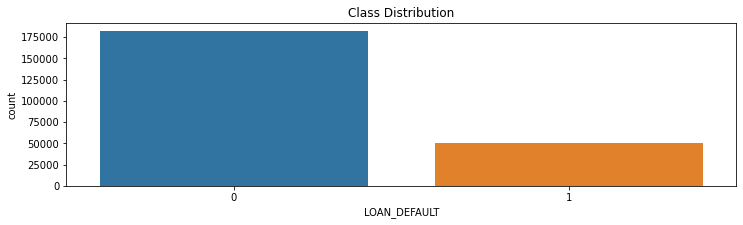

|  | Class Type | Count | Percentage |
| --- | --- | --- | --- |
| 0 | Non Default | 182543 | 78.290000 |
| 1 | Default | 50611 | 21.710000 |

```python
# Graph
plt.figure(figsize = (12, 3))
ax = sns.countplot(x = 'LOAN_DEFAULT', data = df)
plt.title('Class Distribution')
plt.show()

# Value count and its percentage
Total_l = len(df['LOAN_DEFAULT'])
Count_Normal_Trans = len(df[df['LOAN_DEFAULT']==0])
Count_Fraud_Trans = len(df[df['LOAN_DEFAULT']==1])

Per_of_normal_trans = round(((Count_Normal_Trans/Total_l)*100),2)
Per_of_fraud_trans = round(((Count_Fraud_Trans/Total_l)*100),2)

ld = pd.DataFrame(columns = ['Class Type','Count','Percentage'])
ld['Class Type']=['Non Default','Default']
ld['Count']=[Count_Normal_Trans,Count_Fraud_Trans]
ld['Percentage']=[Per_of_normal_trans,Per_of_fraud_trans]
ld.style.background_gradient(cmap='winter')
```

### High Importance variables

DISBURSED_AMOUNT : Amount of loan disbursed ASSET_COST : Payment default in the first EMI on due date LTV : Loan to Value ratio percentage PERFORM_CNS_SCORE : Bureau Score PRI_NO_OF_ACCTS : Count of total loans taken by the customer at the time of disbursement PRI_OVERDUE_ACCTS : Count of default accounts at the time of disbursement

```python
# Bar Plot for one feature
def plot_dis_box(feature):
    plt.figure(figsize = (20,4))
    plt.subplot(1,2,1)
    sns.distplot(df[feature],color='green',fit = skewnorm, bins=100)

    plt.subplot(1,2,2)
    sns.boxplot(df[feature],color='blue')
```

#### 1. DISBURSED_AMOUNT

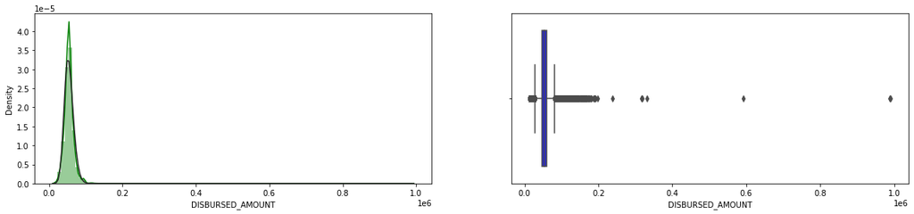

```python
# Subplot

# plt.subplot(#Total number of rows, total num of columns, plot number)
plt.figure(figsize = (20,4))
plt.subplot(1,2,1)
sns.distplot(df.DISBURSED_AMOUNT,color='green',fit = skewnorm, bins=100)

plt.subplot(1,2,2)
sns.boxplot(df.DISBURSED_AMOUNT,color='blue')
```

```python
obs = len(df.DISBURSED_AMOUNT)
print('Before Outlier elimintation\n')
print("No. of observations in column: ",obs)

# calculate summary statistics
data_mean, data_std = mean(df.DISBURSED_AMOUNT), std(df.DISBURSED_AMOUNT)
print('Statistics: Mean=%.3f, Std dev=%.3f' % (data_mean, data_std))
# identify outliers
cut_off = data_std * 3
lower, upper = data_mean - cut_off, data_mean + cut_off
# identify outliers
outliers = [x for x in df.DISBURSED_AMOUNT if x < lower or x > upper]
print('Identified outliers: %d' % len(outliers))
```

```
Before Outlier elimintation

No. of observations in column:  233154
Statistics: Mean=54356.994, Std dev=12971.286
Identified outliers: 3076
```

```python
def impute_outlier(x):

    if x <= lower:
        return(data_mean)
    elif x >= upper:
        return(data_mean)
    else:
        return(x)
```

```python
#After Outlier elimintation
print('\n\nAfter Outlier elimintation\n')
df['DISBURSED_AMOUNT_new']= df['DISBURSED_AMOUNT'].apply(impute_outlier)

obs = len(df.DISBURSED_AMOUNT_new)
print('Before Outlier elimintation\n')
print("No. of observations in column: ",obs)

# calculate summary statistics
data_mean, data_std = mean(df.DISBURSED_AMOUNT_new), std(df.DISBURSED_AMOUNT_new)
print('Statistics: Mean=%.3f, Std dev=%.3f' % (data_mean, data_std))
# identify outliers
cut_off = data_std * 3
lower, upper = data_mean - cut_off, data_mean + cut_off
# identify outliers
outliers = [x for x in df.DISBURSED_AMOUNT_new if x < lower or x > upper]
print('Identified outliers: %d' % len(outliers))
```

```
After Outlier elimintation

Before Outlier elimintation

No. of observations in column:  233154
Statistics: Mean=53736.641, Std dev=11177.432
Identified outliers: 1680
```

#### 2. ASSET_COST

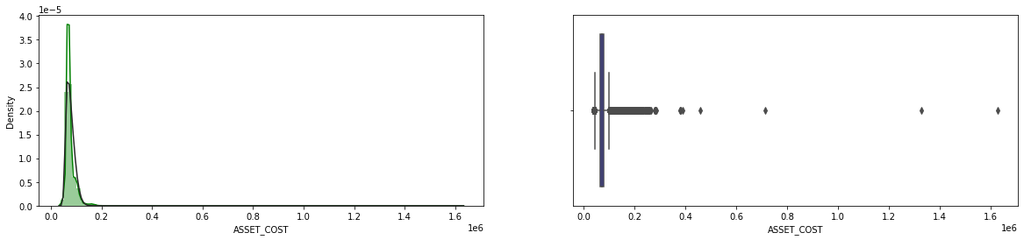

```python
plot_dis_box('ASSET_COST')
```

```python
# OUTLIER TREATMENT

obs = len(df.ASSET_COST)
print('Before Outlier elimintation\n')
print("No. of observations in column: ",obs)

# calculate summary statistics
data_mean, data_std = mean(df.ASSET_COST), std(df.ASSET_COST)
print('Statistics: Mean=%.3f, Std dev=%.3f' % (data_mean, data_std))
# identify outliers
cut_off = data_std * 3
lower, upper = data_mean - cut_off, data_mean + cut_off
# identify outliers
outliers = [x for x in df.ASSET_COST if x < lower or x > upper]
print('Identified outliers: %d' % len(outliers))

#After Outlier elimintation
print('\n\nAfter Outlier elimintation\n')

df["ASSET_COST_new"]= df["ASSET_COST"].apply(impute_outlier)

obs = len(df.ASSET_COST_new)
print("No. of observations in column: ",obs)

# calculate summary statistics
data_mean, data_std = mean(df.ASSET_COST_new), std(df.ASSET_COST_new)
print('Statistics: Mean=%.3f, Std dev=%.3f' % (data_mean, data_std))
# identify outliers
cut_off = data_std * 3
lower, upper = data_mean - cut_off, data_mean + cut_off
# identify outliers
outliers = [x for x in df.ASSET_COST_new if x < lower or x > upper]
print('Identified outliers: %d' % len(outliers))
```

```
Before Outlier elimintation

No. of observations in column:  233154
Statistics: Mean=75865.068, Std dev=18944.741
Identified outliers: 4425


After Outlier elimintation

No. of observations in column:  233154
Statistics: Mean=74272.681, Std dev=14074.345
Identified outliers: 3425
```

#### 3. LTV

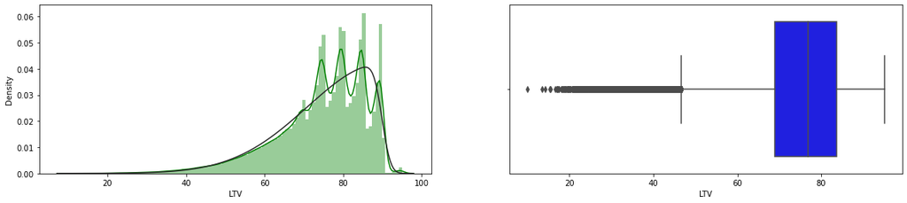

```python
plot_dis_box('LTV')
```

```python
# OUTLIER TREATMENT

obs = len(df.LTV)
print('Before Outlier elimintation\n')
print("No. of observations in column: ",obs)

# calculate summary statistics
data_mean, data_std = mean(df.LTV), std(df.LTV)
print('Statistics: Mean=%.3f, Std dev=%.3f' % (data_mean, data_std))
# identify outliers
cut_off = data_std * 3
lower, upper = data_mean - cut_off, data_mean + cut_off
# identify outliers
outliers = [x for x in df.LTV if x < lower or x > upper]
print('Identified outliers: %d' % len(outliers))

#After Outlier elimintation
print('\n\nAfter Outlier elimintation\n')

df["LTV_new"]= df["LTV"].apply(impute_outlier)

obs = len(df.LTV_new)
print("No. of observations in column: ",obs)

# calculate summary statistics
data_mean, data_std = mean(df.LTV_new), std(df.LTV_new)
print('Statistics: Mean=%.3f, Std dev=%.3f' % (data_mean, data_std))
# identify outliers
cut_off = data_std * 3
lower, upper = data_mean - cut_off, data_mean + cut_off
# identify outliers
outliers = [x for x in df.LTV_new if x < lower or x > upper]
print('Identified outliers: %d' % len(outliers))
```

```
Before Outlier elimintation

No. of observations in column:  233154
Statistics: Mean=74.747, Std dev=11.457
Identified outliers: 2745


After Outlier elimintation

No. of observations in column:  233154
Statistics: Mean=75.223, Std dev=10.558
Identified outliers: 1435
```

#### 4. PERFORM_CNS_SCORE : Bureau Score

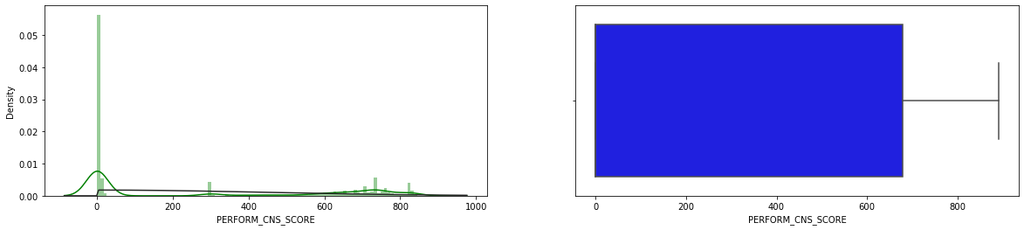

```python
plot_dis_box('PERFORM_CNS_SCORE')
```

```python
# OUTLIER Check

outlier_data(df,'PERFORM_CNS_SCORE')
```

```
No. of observations in column:  233154
Statistics: Mean=289.463, Std dev=338.374
Identified outliers: 0
```

```python
# No outliers found.

# Since we have PERFORM_CNS_SCORE_Description
# We are going to use binning method to categories the varible

# Bin Label
bin_labels = ["No History",'Very High Risk', "High Risk" ,'Medium Risk', 'Low Risk']
# Bin range
cut_bins = [-1,10,150, 350, 650, 1000]


df['PERFORM_CNS_SCORE_bins'] = pd.cut(df['PERFORM_CNS_SCORE'],
                              bins=cut_bins,
                              labels=bin_labels)
df['PERFORM_CNS_SCORE_bins'].value_counts()
```

```
No History        116950
Low Risk           65034
Medium Risk        28425
Very High Risk     12835
High Risk           9910
Name: PERFORM_CNS_SCORE_bins, dtype: int64
```

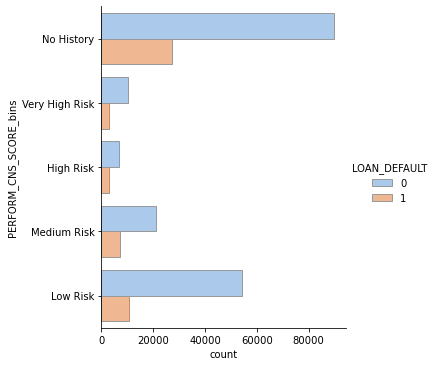

```python
# Bar Graph

def plot_bar(feature):
    plt.figure(figsize=(10,50))
    sns.catplot(y=feature, hue="LOAN_DEFAULT", kind="count",
            palette="pastel", edgecolor=".6",
            data=df);

plot_bar('PERFORM_CNS_SCORE_bins')
```

```python
df.groupby(["PERFORM_CNS_SCORE_DESCRIPTION"]).PERFORM_CNS_SCORE_bins.value_counts()
```

```
PERFORM_CNS_SCORE_DESCRIPTION                            PERFORM_CNS_SCORE_bins
A-Very Low Risk                                          Low Risk                   14124
B-Very Low Risk                                          Low Risk                    9201
C-Very Low Risk                                          Low Risk                   16045
D-Very Low Risk                                          Low Risk                   11358
E-Low Risk                                               Low Risk                    5821
F-Low Risk                                               Low Risk                    8485
G-Low Risk                                               Medium Risk                 3988
H-Medium Risk                                            Medium Risk                 6855
I-Medium Risk                                            Medium Risk                 5557
J-High Risk                                              Medium Risk                 3748
K-High Risk                                              Medium Risk                 8277
L-Very High Risk                                         High Risk                   1134
M-Very High Risk                                         High Risk                   8776
No Bureau History Available                              No History                116950
Not Scored: More than 50 active Accounts found           Very High Risk                 3
Not Scored: No Activity seen on the customer (Inactive)  Very High Risk              2885
Not Scored: No Updates available in last 36 months       Very High Risk              1534
Not Scored: Not Enough Info available on the customer    Very High Risk              3672
Not Scored: Only a Guarantor                             Very High Risk               976
Not Scored: Sufficient History Not Available             Very High Risk              3765
Name: PERFORM_CNS_SCORE_bins, dtype: int64
```

#### 5. PRI_NO_OF_ACCTS : count of total loans taken by the customer at the time of disbursement

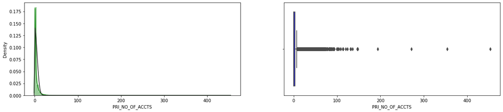

```python
plot_dis_box('PRI_NO_OF_ACCTS')
```

```python
# OUTLIER TREATMENT

obs = len(df.PRI_NO_OF_ACCTS)
print('Before Outlier elimintation\n')
print("No. of observations in column: ",obs)

# calculate summary statistics
data_mean, data_std = mean(df.PRI_NO_OF_ACCTS), std(df.PRI_NO_OF_ACCTS)
print('Statistics: Mean=%.3f, Std dev=%.3f' % (data_mean, data_std))
# identify outliers
cut_off = data_std * 3
lower, upper = data_mean - cut_off, data_mean + cut_off
# identify outliers
outliers = [x for x in df.PRI_NO_OF_ACCTS if x < lower or x > upper]
print('Identified outliers: %d' % len(outliers))

#After Outlier elimintation
print('\n\nAfter Outlier elimintation\n')

df["PRI_NO_OF_ACCTS_new"]= df["PRI_NO_OF_ACCTS"].apply(impute_outlier)

obs = len(df.PRI_NO_OF_ACCTS_new)
print("No. of observations in column: ",obs)

# calculate summary statistics
data_mean, data_std = mean(df.PRI_NO_OF_ACCTS_new), std(df.PRI_NO_OF_ACCTS_new)
print('Statistics: Mean=%.3f, Std dev=%.3f' % (data_mean, data_std))
# identify outliers
cut_off = data_std * 3
lower, upper = data_mean - cut_off, data_mean + cut_off
# identify outliers
outliers = [x for x in df.PRI_NO_OF_ACCTS_new if x < lower or x > upper]
print('Identified outliers: %d' % len(outliers))
```

```
Before Outlier elimintation

No. of observations in column:  233154
Statistics: Mean=2.441, Std dev=5.217
Identified outliers: 4119


After Outlier elimintation

No. of observations in column:  233154
Statistics: Mean=1.980, Std dev=3.269
Identified outliers: 7064
```

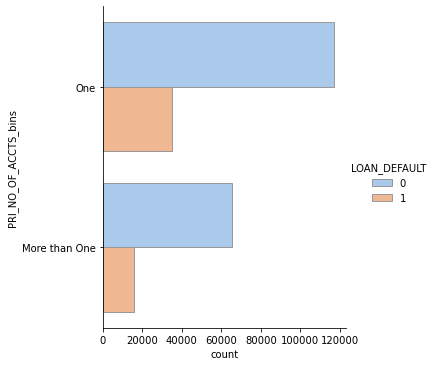

```python
# Binning

bin_labels = ["One",'More than One']
cut_bins = [-1,1, 1000]

df['PRI_NO_OF_ACCTS_bins'] = pd.cut(df['PRI_NO_OF_ACCTS'],
                              bins=cut_bins,
                              labels=bin_labels)
df['PRI_NO_OF_ACCTS_bins'].value_counts()

plot_bar('PRI_NO_OF_ACCTS_bins')
```

#### 6. PRI_OVERDUE_ACCTS

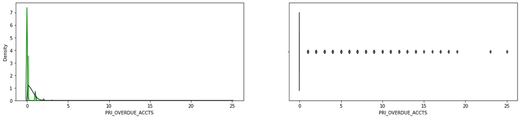

```python
plot_dis_box('PRI_OVERDUE_ACCTS')
```

```python
# OUTLIER TREATMENT

obs = len(df.PRI_OVERDUE_ACCTS)
print('Before Outlier elimintation\n')
print("No. of observations in column: ",obs)

# calculate summary statistics
data_mean, data_std = mean(df.PRI_OVERDUE_ACCTS), std(df.PRI_OVERDUE_ACCTS)
print('Statistics: Mean=%.3f, Std dev=%.3f' % (data_mean, data_std))
# identify outliers
cut_off = data_std * 3
lower, upper = data_mean - cut_off, data_mean + cut_off
# identify outliers
outliers = [x for x in df.PRI_OVERDUE_ACCTS if x < lower or x > upper]
print('Identified outliers: %d' % len(outliers))

#After Outlier elimintation
print('\n\nAfter Outlier elimintation\n')

df["PRI_OVERDUE_ACCTS_new"]= df["PRI_OVERDUE_ACCTS"].apply(impute_outlier)

obs = len(df.PRI_NO_OF_ACCTS_new)
print("No. of observations in column: ",obs)

# calculate summary statistics
data_mean, data_std = mean(df.PRI_OVERDUE_ACCTS_new), std(df.PRI_OVERDUE_ACCTS_new)
print('Statistics: Mean=%.3f, Std dev=%.3f' % (data_mean, data_std))
# identify outliers
cut_off = data_std * 3
lower, upper = data_mean - cut_off, data_mean + cut_off
# identify outliers
outliers = [x for x in df.PRI_OVERDUE_ACCTS_new if x < lower or x > upper]
print('Identified outliers: %d' % len(outliers))
```

```
Before Outlier elimintation

No. of observations in column:  233154
Statistics: Mean=0.157, Std dev=0.549
Identified outliers: 6305


After Outlier elimintation

No. of observations in column:  233154
Statistics: Mean=0.090, Std dev=0.280
Identified outliers: 19970
```

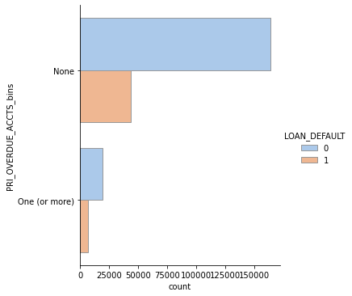

```python
# Binning

bin_labels = ["None",'One (or more)']
cut_bins = [-1,0, 1000]

df['PRI_OVERDUE_ACCTS_bins'] = pd.cut(df['PRI_OVERDUE_ACCTS'],
                              bins=cut_bins,
                              labels=bin_labels)
plot_bar('PRI_OVERDUE_ACCTS_bins')
```

### Less Important variables

MOBILENO_AVL_FLAG : if Mobile no. was shared by the customer then flagged as 1 AADHAR_FLAG : if aadhar was shared by the customer then flagged as 1 PAN_FLAG : if pan was shared by the customer then flagged as 1 VOTERID_FLAG : if voter was shared by the customer then flagged as 1 PASSPORT_FLAG : if passport was shared by the customer then flagged as 1 DRIVING_FLAG : if DL was shared by the customer then flagged as 1

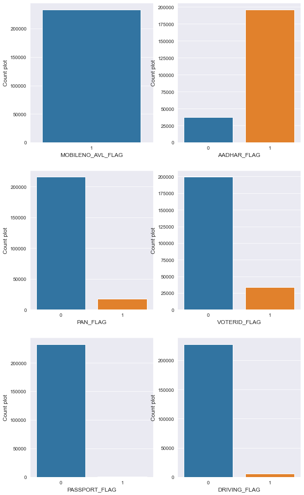

```python
# Plot the graph for the less important variables

# create feature list
var = ['MOBILENO_AVL_FLAG','AADHAR_FLAG','PAN_FLAG','VOTERID_FLAG','PASSPORT_FLAG','DRIVING_FLAG']



def plot_bar_comp(var,nrow=2):

    i = 0
    sns.set_style('darkgrid')
    plt.figure()
    fig, ax = plt.subplots(nrow,2,figsize=(10,6*nrow))

    for feature in var:
        i += 1
        plt.subplot(nrow,2,i)
        sns.countplot(df[feature])
        sns.countplot(df[feature])
        plt.ylabel('Count plot', fontsize=12)
        plt.xlabel(feature, fontsize=12)
        locs, labels = plt.xticks()
        plt.tick_params(axis='both', which='major', labelsize=10)
    plt.show();


plot_bar_comp(var,nrow=3)
```

#### EMPLOYMENT TYPE

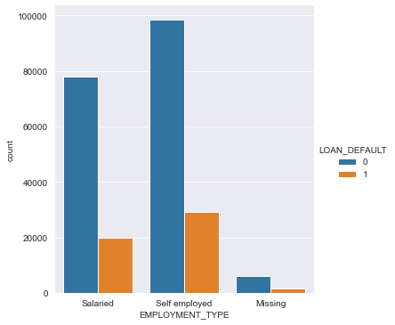

```python
sns.catplot(data=df,kind='count',x='EMPLOYMENT_TYPE',hue='LOAN_DEFAULT')
```

#### Customer Age

```python
# Calculation


# Current Date and Time
now = pd.Timestamp('now')

# Age Calculation
df['age'] = (now - df['DATE_OF_BIRTH'])

df['age']= df['age'].astype(str)
df[['age','age_waste']] = df['age'].str.split("days",expand=True)
df['age']= df['age'].astype(str).astype(int)
df= df.drop(columns= ['age_waste'])

days_in_year = 365.2425
df['age']=(round(df['age']/days_in_year))
df['age']=df['age'].astype(int)
```

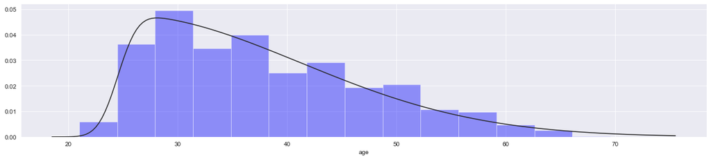

```python
# Distribution Plot

plt.figure(figsize = (20,4))
sns.distplot(df.age,color='blue',fit = skewnorm, bins=15,kde=False)
```

```python
# Plot distribution of multiple features, with TARGET = 1/0 on the same graph
def plot_distribution_comp(var,nrow=2):

    i = 0
    t1 = df.loc[df['LOAN_DEFAULT'] != 0]
    t0 = df.loc[df['LOAN_DEFAULT'] == 0]

    sns.set_style('whitegrid')
    plt.figure()
    fig, ax = plt.subplots(nrow,2,figsize=(18,5*nrow))

    for feature in var:
        i += 1
        plt.subplot(nrow,2,i)
        sns.kdeplot(t1[feature], bw=0.5,label="LOAN_DEFAULT = 1")
        sns.kdeplot(t0[feature], bw=0.5,label="LOAN_DEFAULT = 0")
        plt.ylabel('Density plot', fontsize=12)
        plt.xlabel(feature, fontsize=12)
        locs, labels = plt.xticks()
        plt.tick_params(axis='both', which='major', labelsize=12)
    plt.show();
```

#### Primary acount details in distribution

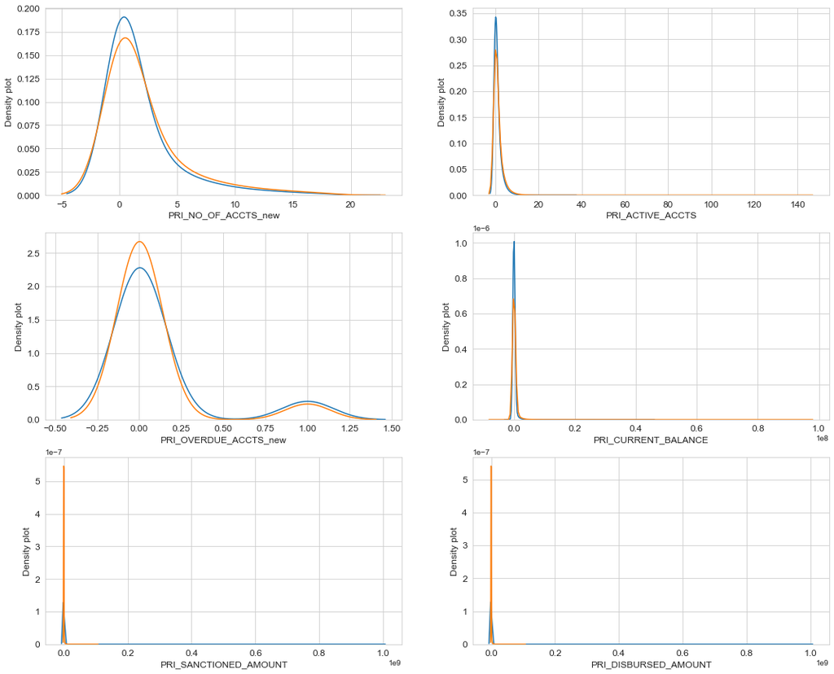

```python
var = ['PRI_NO_OF_ACCTS_new', 'PRI_ACTIVE_ACCTS', 'PRI_OVERDUE_ACCTS_new',
       'PRI_CURRENT_BALANCE', 'PRI_SANCTIONED_AMOUNT', 'PRI_DISBURSED_AMOUNT']

plot_distribution_comp(var,nrow=3)
```

#### Secondary acount details in distribution

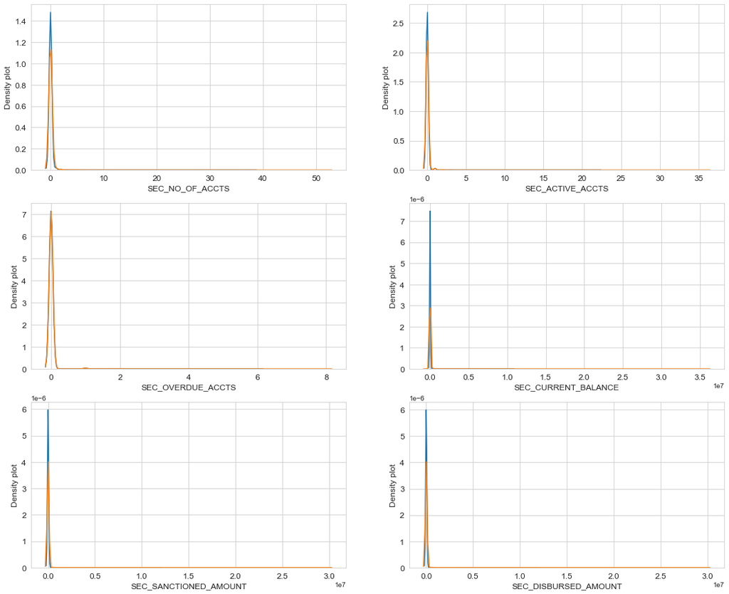

```python
var = ['SEC_NO_OF_ACCTS', 'SEC_ACTIVE_ACCTS', 'SEC_OVERDUE_ACCTS', 'SEC_CURRENT_BALANCE',
       'SEC_SANCTIONED_AMOUNT', 'SEC_DISBURSED_AMOUNT']
plot_distribution_comp(var,nrow=3)
```

## 7. Correlation Matrix

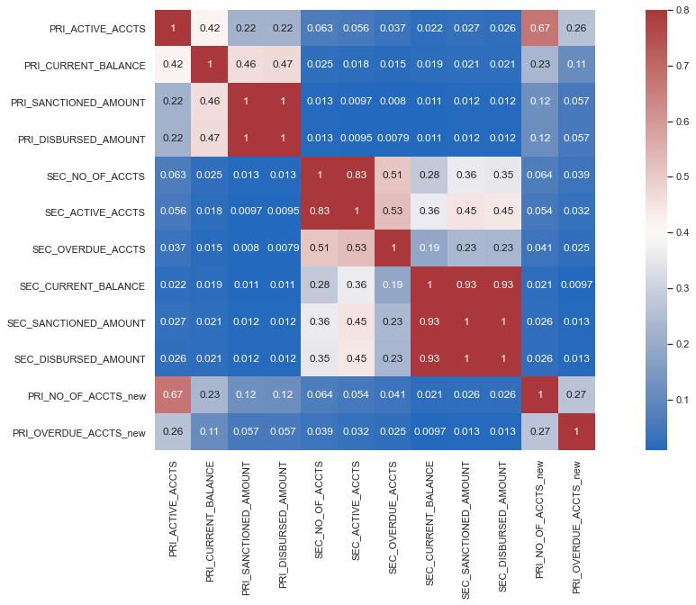

```python
sns.set()

cols = df[['PRI_ACTIVE_ACCTS', 'PRI_CURRENT_BALANCE', 'PRI_SANCTIONED_AMOUNT', 'PRI_DISBURSED_AMOUNT',
              'SEC_NO_OF_ACCTS', 'SEC_ACTIVE_ACCTS', 'SEC_OVERDUE_ACCTS', 'SEC_CURRENT_BALANCE', 'SEC_SANCTIONED_AMOUNT',
              'SEC_DISBURSED_AMOUNT',  'PRI_NO_OF_ACCTS_new', 'PRI_OVERDUE_ACCTS_new']]
corr = cols.corr()
f, ax = plt.subplots(figsize=(20, 9))
sns.heatmap(corr, annot=True, vmax=.8, square=True,cmap = 'vlag');
```

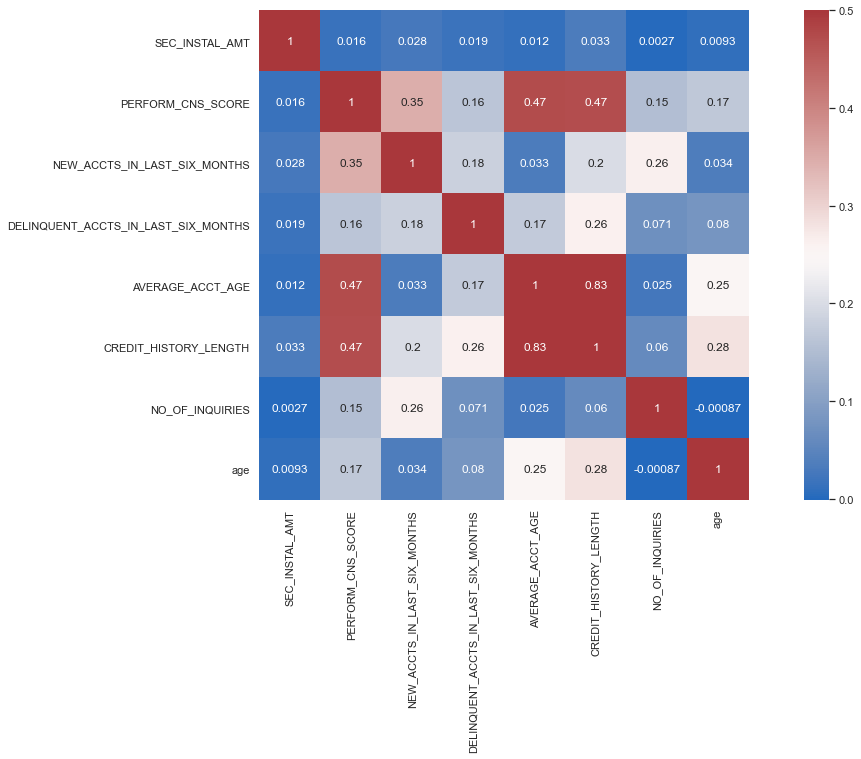

```python
sns.set()

cols = df[['SEC_INSTAL_AMT', 'PERFORM_CNS_SCORE','NEW_ACCTS_IN_LAST_SIX_MONTHS', 'DELINQUENT_ACCTS_IN_LAST_SIX_MONTHS',
              'AVERAGE_ACCT_AGE', 'CREDIT_HISTORY_LENGTH', 'NO_OF_INQUIRIES','age']]
corr = cols.corr()
f, ax = plt.subplots(figsize=(20, 9))
sns.heatmap(corr, annot=True, vmax=0.5, square=True,cmap="vlag");
```

## 8. Conclusion

1. Initially the null values have been identified and replaced.
2. Further from the dataset a list of variable and types need to changed.
3. The comes the EDA were the data set have split into High importance and Low importance variables
4. From the visualization we found variables with outliers and its has been replaced by its mean to make it distribution stable
5. Then the low importance variables with categorical values have been plotted to understand the variables impact
6. Then comes the bar chart from the type of employment by Loan Defaulter
7. Moving indepth the Primary and secondary account details have been plotted through density plot to find the relation between Defaulters and thier documented variables.
8. Finally the variables have been plotted in correlation matrix to find its correlation.